# Tips och tricks

```
## Using libcurl 7.64.1 with Schannel
```

# 1 Om dokumentet

**Senaste uppdateringen: 2021-12-10**

Rapporten innehåller en del exempel på funktioner i R Markdown som vi i Region Halland har arbetat med och som - enligt vår erfarenhet - ofta inte återfinns i standardmanualer. Det är högst sannolikt att koden inte alltid följer “best practice”, utan användning sker på “egen risk”. Materialet ska med andra ord inte ses som ett grundläggande utbildningsmaterial. Ambtionen är att successivt utveckla dokumentet, både vad gäller funktioner och pedagogik.

Förutom funktioner i Markdown i allmänhet kommer i att samla en del diagram och andra tricks i detta dokument.

För frågor eller förbättringsförslag kontakta robin.rikardsson@regionhalland.se eller anton.k.larsson@regionhalland.se

För att kunna köra alla funktioner: Klicka på “Code”-> “Download zip” och kör sedan RMarkdown-filen.

# 2 Allmänna tips och tricks

## 2.1 Gör ditt eget tema

I outputen kan du hänvisa till ett eget .css-dokument där du ställer in allt från teckensnitt till storleken på rubriker. Se dokumentet “style.css” för några exempel. Lägg dokumentet i samma mapp som markdown-filen.

För att skapa ett .css-dokument: Öppna anteckningar -> Spara som -> välj format “Alla filer” -> Skriv namn och sedan filändelsen .css

Obersvera att .css-dokumentet behöver ha samma namn som i outputen ovanför.

## 2.2 Skapa villkorade chunks / textblock

Genom funktionen “eval” kan du ha villkorade textblock. Detta kan fylla en funktion när du arbetar med parametrar för att skapa flera rapporter men vill ha vissa unika textdelar.

```r
data("mtcars")

cylindrar <- mtcars$cyl ## Här väljer vi att vi vill ha unika block för antalet cylindrar

cylindrar <- sample(c(4,6,8), size=1) ## Här slumpar vi fram antalet cylindrar (substitut för parameter i detta exempel)

cylindrar ## Här ser vi vilket slumptal det blev...
```

```
## [1] 6
```

```r
if (cylindrar == 4){ ## Här skriver vi ett villkor: Om det är fyra cylindrar är cyl4 SANT. cyl4 är det villkor vi använder i nästa chunk i anslutning till funktionen "eval"
cyl4 = TRUE
} else {
cyl4 =FALSE
}

if (cylindrar == 6){
cyl6 = TRUE
} else {
cyl6 =FALSE
}

if (cylindrar == 8){
cyl8 = TRUE
} else {
cyl8 =FALSE
}
```

Den här texten kommer endast att visas när SEX cylindrar har slumpats fram.

## 2.3 Skapa en expanderbar flik

En fördel med Markdown är att man kan använda HTML-kod för en del praktiska funktioner. Nedan följer ett exempel på expanderbar flik som kan användas för att “gömma” en del förklarande text. Exempelvis kan flikarna användas för att öka tillgängligheten då uppläsningsfunktionen i webläsare “hittar” texten som finns i flikarna.

Man kan ändra stilen på flikarna i .css dokumentet.

**Stöd för att tolka diagrammet**

Här kan man ha förklarande text till ett diagram, eller någon annan relevant information.

## 2.4 Skapa diagram i en loop

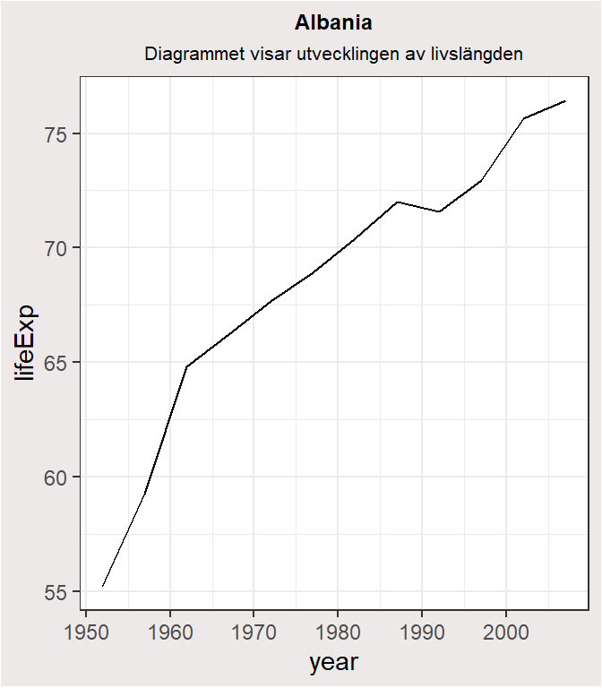

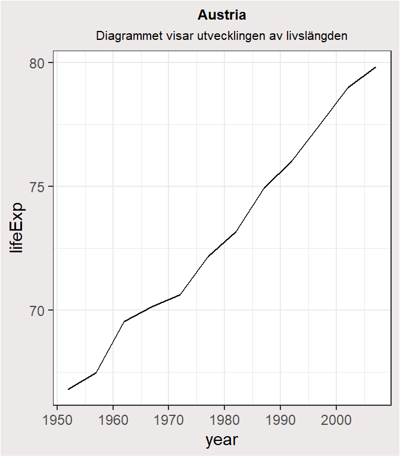

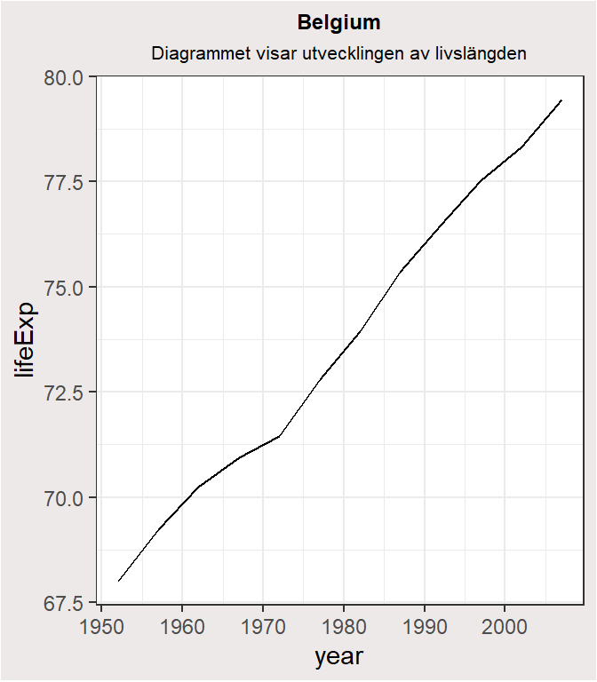

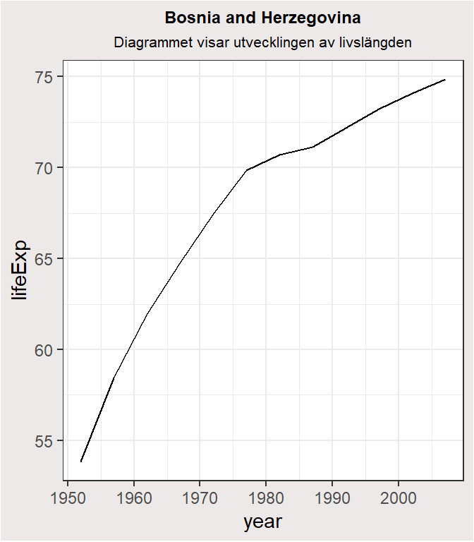

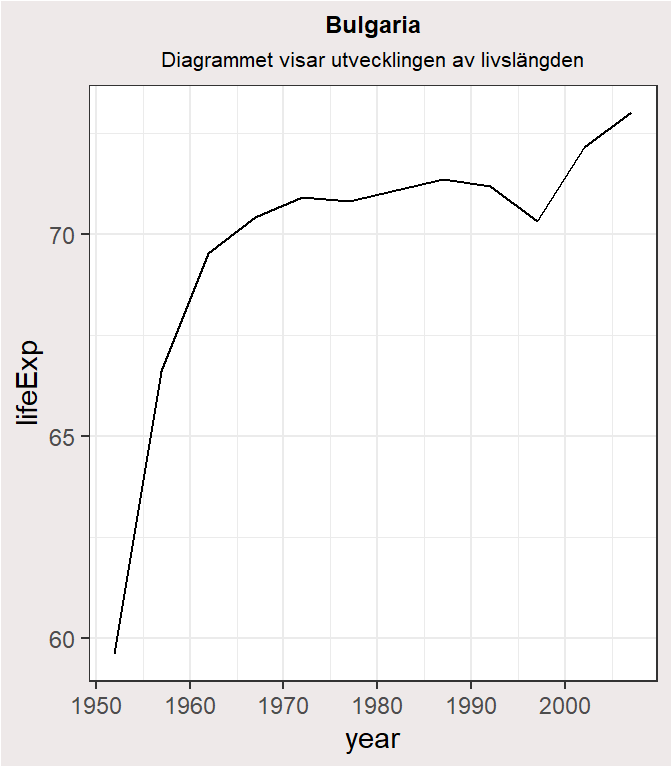

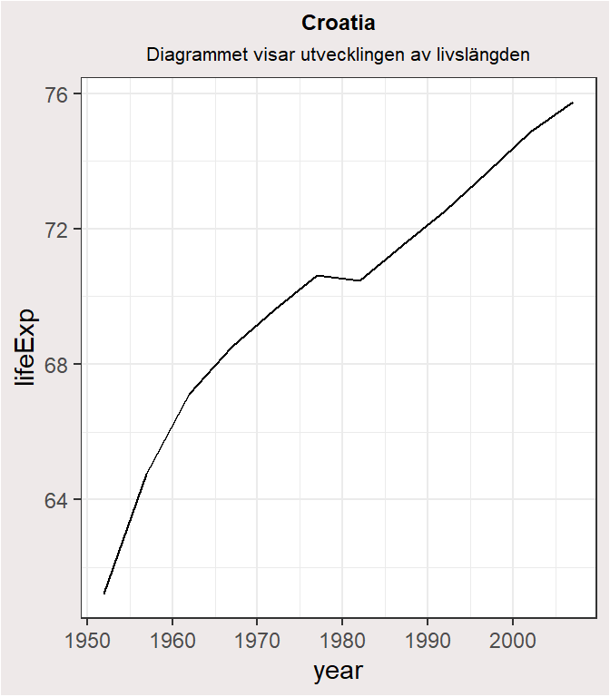

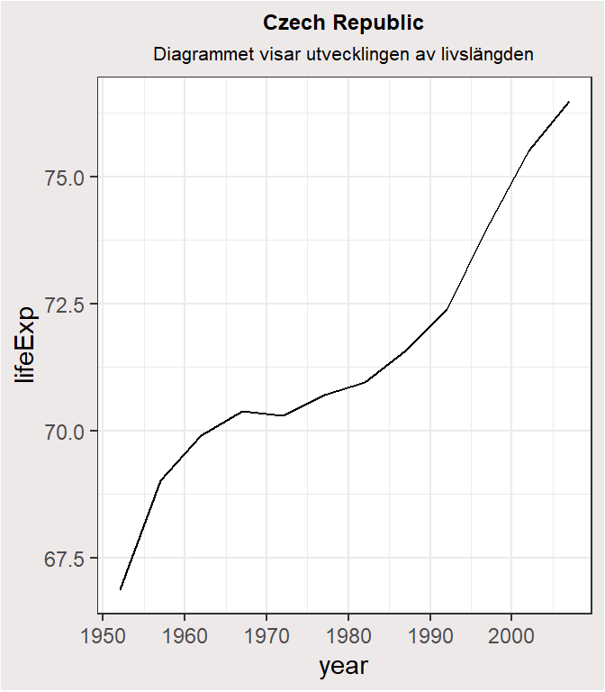

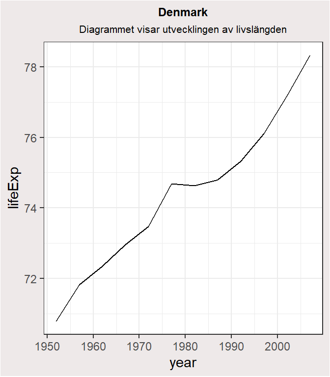

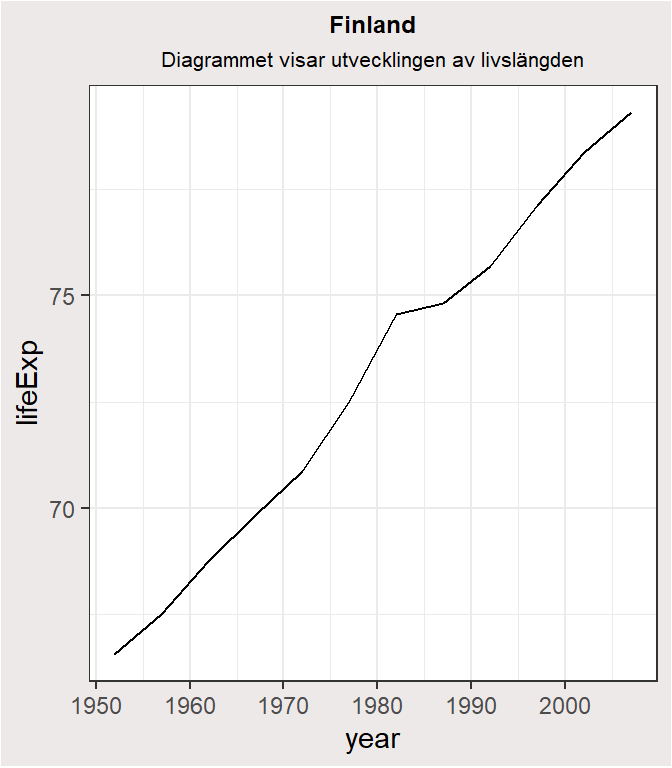

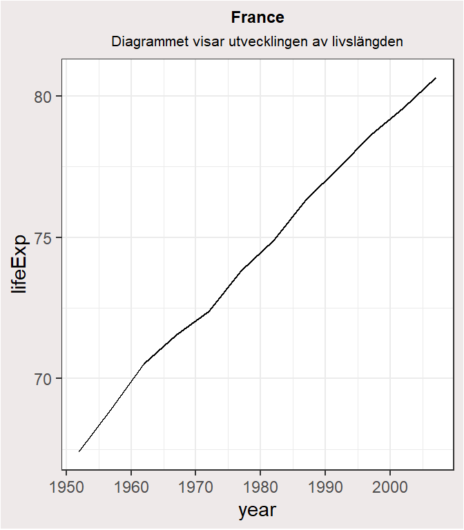

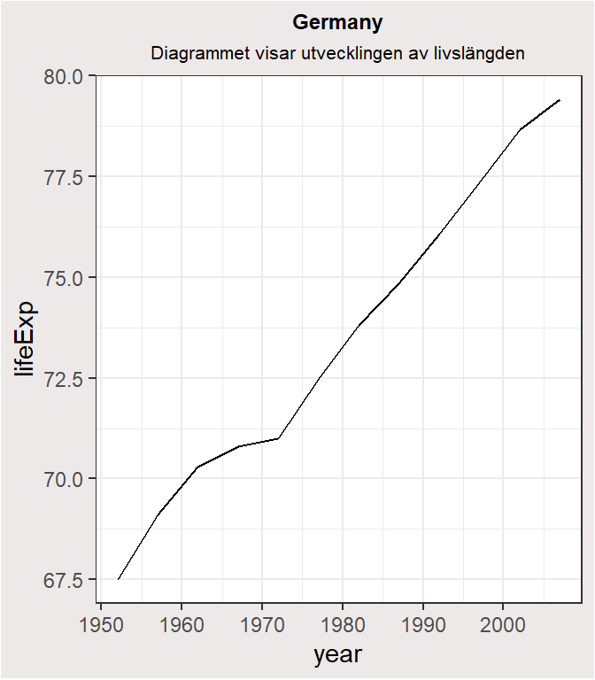

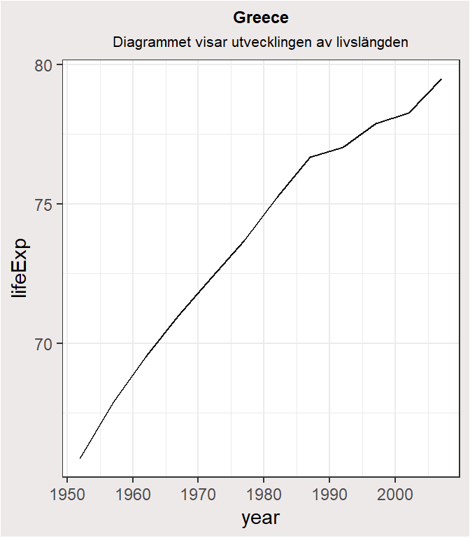

[18 more figures not shown]

# 3 Diagram och grafik